# Lesson 5 Guide

# Lesson 5: Consumption

## Consumption as part of GDP

Consumption accoutns for roughly 2/3 of GDP in the United States. This dictates that it becomes a very important aspect around policy making. From 2001-2007 consumption grew by roughly 3% per year. During the great recession however consumtion fell 0.25% in 2008 and 0.6% in 2009.

## Consumption Theories

In this lesson we look at consumer choice between consumption and saving (or future consumption).

- Theory 1: Intertemporal Choice (Irving Fisher)
  - we look at this
- Theory 2: Keynesian Consumption Function (Econ 104)
- Theory 3: Permanent Income Hypothesis (Friedman)
- Theory 4: Life-Cycle Hypothesis (Modigliani)

## Theory of Intertemporal Choice

### 3 steps to this theory

1. Define the Intertemporal Budget Constraint
2. Define the consumer preferences
3. Show the optimal consumption bundle

## Assumptions

1. Individuals live in a 2 period world
   - Period 1 vs Period 2
   - Current vs Future
   - Today vs Tomorrow
2. No Income/Wealth is left over
   - anything saved in period 1, is consumed in period 2
   - anything borrowed in period 1, is paid back in period 2
3. Savings rate = borrowing rate

## Terminology

Y<sub>i</sub> = Income in period i (Y<sub>1</sub> vs Y<sub>2</sub>)  
W<sub>i</sub> = Wealth in period i  
C<sub>i</sub> = Consumption in period i

(Y<sub>i</sub> + W<sub>i</sub>) = i-Period’s resources

With 2 time periods:

- (Y<sub>1</sub> + W<sub>1</sub>) = current resources
- (Y<sub>2</sub> + W<sub>2</sub>) = future resources
  - Combined they are lifetime resources

## Intertemporal Budget Line

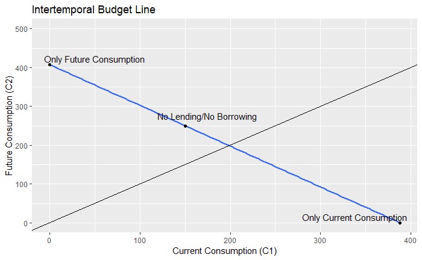

```r
y1 <- 100
w1 <- 50
y2 <- 50
w2 <- 200
r <- 0.05
c1 <- seq(from = 0, to = 500, by = 0.5)
c2 <- ((y1 + w1) * (1 + r) + (y2 + w2)) - (1 + r) * c1
IBL <- data.frame(c1 = c1, c2 = c2)
nlnbc1 <- y1 + w1
nlnbc2 <- y2 + w2
yintercept <- (1 + r) * (y1 + w1) + (y2 + w2)
xintercept <- (y1 + w1) + (y2 + w2) / (1 + r)
IBL %>%
  ggplot(aes(x = c1, y = c2)) +
  geom_smooth() +
  geom_point(aes(x = xintercept, y = 0)) +
  geom_point(aes(x = 0, y = yintercept)) +
  geom_point(aes(x = nlnbc1, y = nlnbc2)) +
  xlab("Current Consumption (C1)") +
  ylab("Future Consumption (C2)") +
  ggtitle("Intertemporal Budget Line") +
  scale_y_continuous(limits = c(0,500)) +
  geom_abline(slope = 1, intercept = 0) +
  annotate(geom = "text", x = xintercept - 50, y = 15,
           label = "Only Current Consumption") +
  annotate(geom = "text", x = 50, y = yintercept + 15,
           label = "Only Future Consumption") +
  annotate(geom = "text", x = nlnbc1 + 25, y = nlnbc2 + 25,
           label = "No Lending/No Borrowing")
```

### Points to observe

- Y-intercept = Only Future consumption (C<sub>2</sub>)
- X-intercept = Only Current consumption (C<sub>1</sub>)
- intserction of IBL and y = x is C<sub>1</sub> = C<sub>2</sub> (Consumption Smoothing)
- No-Lending/No-Borrowing Point
  - C<sub>1</sub> = Y<sub>1</sub> + W<sub>1</sub>
  - C<sub>2</sub> = Y<sub>2</sub> + W<sub>2</sub>
- Slope = -(1 + r)
  - r = real interest rate

## Math of IBL

Assumption 2: PVLC = PVLR

Present Value Lifetime Consumption (PVLC)
$$C_1 + \frac{C_2}{(1 + r)} + \frac{C_3}{(1 + r)^2} + \frac{C_4}{(1 + r)^3} + ... + \frac{C_n}{(1 + r)^{n-1}}$$

Present Value Lifetime Resources (PVLR)
$$(Y_1 + W_1) + \frac{(Y_2 + W_2)}{(1 + r)} + \frac{(Y_3 + W_3)}{(1 + r)^2} + \frac{(Y_4 + W_4)}{(1 + r)^3} + ... + \frac{(Y_n + W_n)}{(1 + r)^{n-1}}$$

When n = 2 you get our IBL:
$$C_1 + \frac{C_2}{(1 + r)} = (Y_1 + W_1) + \frac{(Y_2 + W_2)}{(1 + r)}$$

Put it into `y = mx + b` form:
$$C_2 = -(1 + r) * C_1 + ((Y_1 + W_1)(1 + r) + (Y_2 + W_2))$$

## Shifts of the IBL

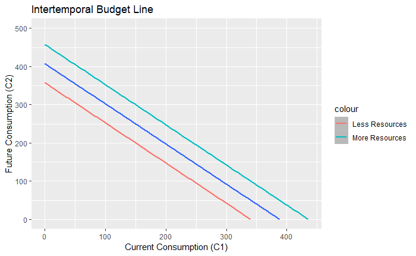

```r
IBL$c2up <- IBL$c2 + 50
IBL$c2down <- IBL$c2 - 50
IBL %>%
  ggplot(aes(x = c1, y = c2)) +
  geom_smooth() +
  geom_smooth(aes(y = c2up, color = "More Resources")) +
  geom_smooth(aes(y = c2down, color= "Less Resources")) +
  xlab("Current Consumption (C1)") +
  ylab("Future Consumption (C2)") +
  ggtitle("Intertemporal Budget Line") +
  scale_y_continuous(limits = c(0,500))
```

Green (Shifts up/right): * Increase in Y<sub>1</sub>, Y<sub>2</sub>, W<sub>1</sub>, W<sub>2</sub>

Red (Shifts down/left): * Decrease in Y<sub>1</sub>, Y<sub>2</sub>, W<sub>1</sub>, W<sub>2</sub>

## Rotation of the IBL

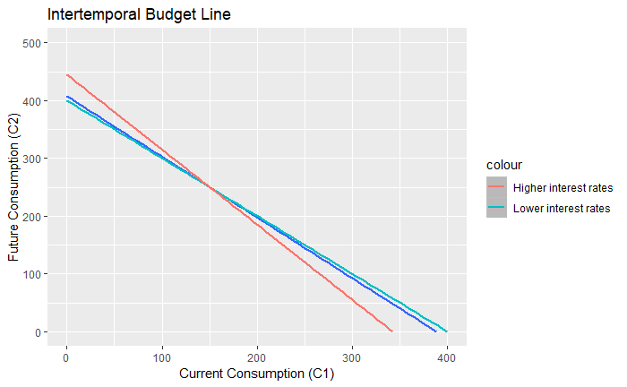

```r
r <- 0
IBL$c2slow <- ((y1 + w1) * (1 + r) + (y2 + w2)) - (1 + r) * IBL$c1
r <- 0.3
IBL$c2steep <- ((y1 + w1) * (1 + r) + (y2 + w2)) - (1 + r) * IBL$c1
IBL %>%
  ggplot(aes(x = c1, y = c2)) +
  geom_smooth() +
  geom_smooth(aes(y = c2slow, color = "Lower interest rates")) +
  geom_smooth(aes(y = c2steep, color= "Higher interest rates")) +
  xlab("Current Consumption (C1)") +
  ylab("Future Consumption (C2)") +
  ggtitle("Intertemporal Budget Line") +
  scale_y_continuous(limits = c(0,500))
```

An increase in r (real interest rate) correponds to a steeper slope and a decrease in r corresponds to a shallower slope. This makes sense since the slope is -(1 + r)

## Preferences

The question: what combination of C<sub>1</sub> and C<sub>2</sub> would make an individual equally happy?

Use an indifference curve.

```
Ignoring unknown aesthetics: cIgnoring unknown aesthetics: c
```

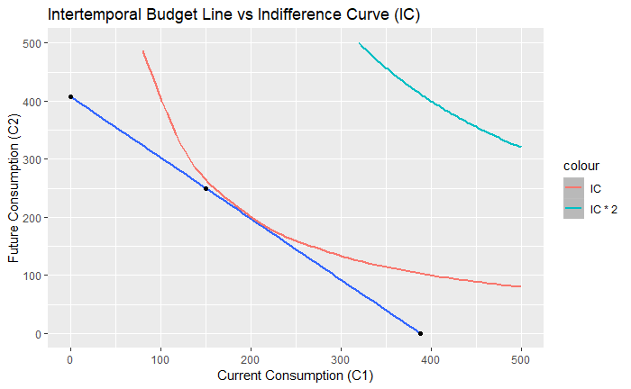

```r
util <- 200
IBL$indiff <- (util / c1 ^ 0.5) ^ 2
IBL$indiffDouble <- (util * 2 / c1 ^ 0.5) ^ 2
IBL %>%
  ggplot(aes(x = c1, y = c2)) +
  geom_smooth() +
  geom_smooth(aes(c = c1, y = indiff, color = "IC")) +
  geom_smooth(aes(c = c1, y = indiffDouble, color = "IC * 2")) +
  geom_point(aes(x = xintercept, y = 0)) +
  geom_point(aes(x = 0, y = yintercept)) +
  geom_point(aes(x = nlnbc1, y = nlnbc2)) +
  xlab("Current Consumption (C1)") +
  ylab("Future Consumption (C2)") +
  ggtitle("Intertemporal Budget Line vs Indifference Curve (IC)") +
  scale_y_continuous(limits = c(0,500))
```

The indifference curve used in the example is at a utility of 200 for a cobb douglas utility function of $U = C_1^{0.5} * C_2^{0.5}$

If “Marissa” always consumptions smooths, then you want to find the point on the graph where C<sub>1</sub> = C<sub>2</sub>

### To find C*:

1. Preference (C<sub>1</sub> = C<sub>2</sub>)
2. IBL (PVLR = PVLC)

$$C_1 + \frac{C_2}{(1 + r)} = (Y_1 + W_1) + \frac{(Y_2 + W_2)}{(1 + r)}$$
Replace C<sub>2</sub> with C<sub>1</sub>, since they are equal when smoothing
$$C_1 + \frac{C_1}{(1 + r)} = (Y_1 + W_1) + \frac{(Y_2 + W_2)}{(1 + r)}$$
$$(1 + r) * C_1 + C_1 = (1 + r)(Y_1 + W_1) + (Y_2 + W_2)$$
$$C^* = \frac{(1 + r)(Y_1 + W_1) + (Y_2 + W_2)}{(2 + r)}$$

What if “Sam” prefers to consume twice as much in the future period?

1. C<sub>1</sub> = 0.5 * C<sub>2</sub>
2. IBL

$$C_1^* = \frac{(1 + r)(Y_1 + W_1) + (Y_2 + W_2)}{(3 + r)}$$

How does changes in r (real interest rate) affect consumption?

## Substitution Effect

If r increases, then C<sub>1</sub> is more expensive for both borrowers and savers.

Therefore, C<sub>1</sub> goes down and C<sub>2</sub> goes up, for both types.

- Sub into “cheaper” good

## Income Effect

If r increases

- Borrower has less real income, so all consumption goes down
- Saver has more real income, so all consumption goes up

When looking at data, when the real interest rate increases, C<sub>1</sub> decreases, so the substitution effect is stronger than the income effect.